# Terror Data Project

### Optimization of Model

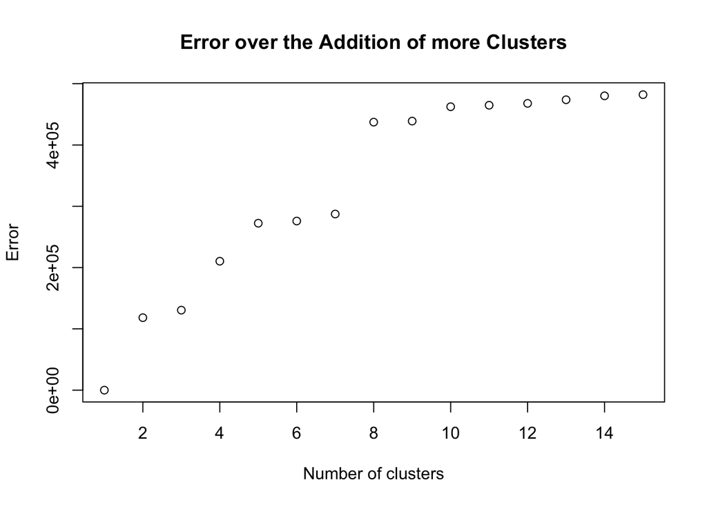

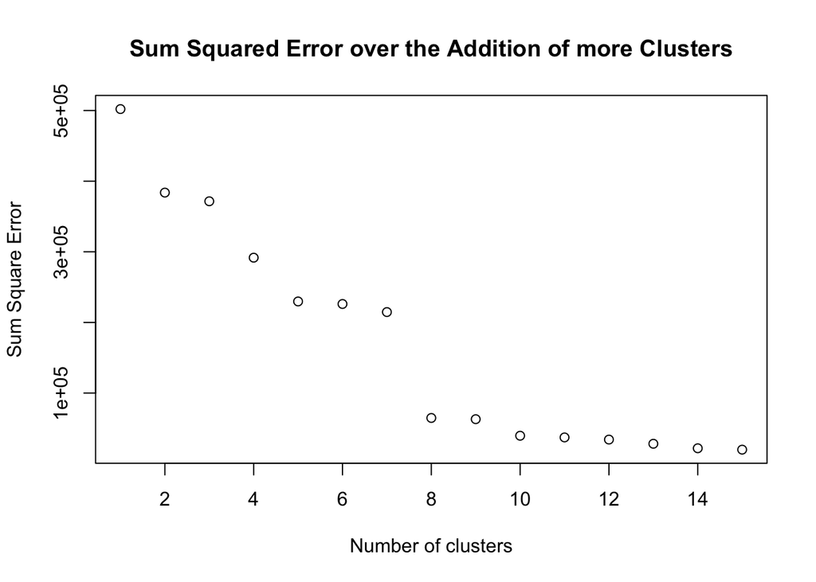

#### Description of Optimization of Model:

To find the optimal number of clusters to use in our kmeans model we created a for loop that ran our cluster model with an additional cluster each time and recorded the Error and Sum Square Error after the addition of a new cluster to the model. This was then plotted to show graphicly when the addition of a new cluster had little to no change on the error and Sum Squared Error. It’s clear from the two graphics that after 8 clusters the addition of any more has little to no change to the Sum Squared Error and the Error numbers therefore 8 clusters is the optimal number for this kmeans model.